# Outline Metadata

Rainer M. Krug

23 November, 2018

# Introduction

This scheme will provide a framework for describing aquatic microcosm experiments in the sense as used in the papers in the [Reference] section.

This scheme **aims to** cover the following aspects:

1. **Materials**: these include instrumentation, species, cultures, …
2. **Initialization**: run in time, treatment, conditions
3. **Conditions / Manipulations**: different conditions for the different treatments and manipulations, conditions, transplantations, …
4. **Sampling** (how much is taken from microcosms and how much is re-filled with what and how often, …)
5. **Measuring** of the raw data (video, images, count, …) using different methodologies and their instrumentations, protocols, …
6. **Extraction** of the needed measure (density, …) from the measured raw data (if needed) and the software, versions, parameter used (e.b. bemovi)

By using this metadata one should be able to successfully re-generate the data.

This scheme **does not** aim to cover aspects of the actual analysis of this data with the aim of answering specific questions.

# The emeScheme

## Experimental Microbial Ecology Protocols

In the [supplement to their paper](https://emeh-protocols.readthedocs.io/en/latest/) to their paper, Altermatt et al. (2015) specify the following sections for a protocoll. The sections are as followed:

```
1. Materials
1.1 Species used
1.2 Culture medium
1.3 Bacteria
1.4 Apparatus
1.5 Lab practices
1.6 Long term maintenance
1.7 Long term preservation
2. Measurements
2.1 Sampling
2.2 Microscopy
2.3 Image analysis
2.4 Particle counter
2.5 Bacterial density
2.6 Raman microspectroscopy
2.7 Barcoding
2.8 Ge-, prote- and epigenomics
2.9 Respirometry
2.10 Nutrients and decomposition
2.11 Protocol unavailable
2.12 Interactions
3. Manipulations
3.1 Protocol unavailable
3.2 Density
3.3 Disturbance
3.4 Nutrients and viscosity
3.5 Spatial structure
3.6 temperature
3.7 Biotic environment
```

We use these sections as a starting point to define a metadata scheme to describe the microcosm experiment.

## Supplementing, Re-ordfering and Thinning

This document was than re-ordered and thinned which resulted in the initial verions of [the Google Doc Sheet](https://docs.google.com/spreadsheets/d/1OAyRM1jGL5Vho-YfPffePhwGpQtaBUeTPJV6P98f0Bc).

Here we describe the different properties of the emeScheme We will start at the first level and go deeper into the different properties.

The working copy can be found on a [Google Doc Sheet](https://docs.google.com/spreadsheets/d/1OAyRM1jGL5Vho-YfPffePhwGpQtaBUeTPJV6P98f0Bc).

## Current Structure

The names of the proiperties folow the following convention:

- Properties starting with a **capital letters** contain sub-properties, i.e. can be considered as **property sets**
- Properties starting with a **small letter** contain actual values of the types **character** or **numeric**. **types need to be specified**

**Inclusde mandatory, repeatable, …** The structure as currently (last version updated at 2018-11-23 09:20:26) is as followed:

emeScheme Properties.

| Property Level 1 | Property Level 2 | Property Level 3 | Property Level 4 | Property Level 5 |
| --- | --- | --- | --- | --- |
| Experimental Layout |  |  |  |  |
|  | no of treatments |  |  |  |
|  | no of replicates per treatment |  |  |  |
|  | description |  |  |  |
| Materials |  |  |  |  |
|  | Apparatus |  |  |  |
|  |  | Incubators |  |  |
|  |  |  | type / version, … |  |
|  |  | Container |  |  |
|  |  |  | type |  |
|  |  |  | volume |  |
|  |  |  | covers |  |
|  |  | Shakers |  |  |
|  |  |  | make / type |  |
|  |  |  | speed (rpm) |  |
|  | Species |  |  |  |
|  |  | species |  |  |
|  |  | strain |  |  |
|  |  | source |  |  |
|  |  | density (cells/ml) |  |  |
|  | Culture medium |  |  |  |
|  |  | volume |  |  |
|  |  | type |  |  |
|  | Bacteria + Flagellates |  |  |  |
|  |  | species |  |  |
|  |  | strain |  |  |
|  |  | source / pellet |  |  |
|  |  | density (cells/ml) |  |  |
|  | Lab practices |  |  |  |
|  | Long term maintenance |  |  |  |

[output cut: 73 more lines]

# From Project to Dataset - how the emeScheme fits in

Data can be separated into different classes. Each of these classes sontains of **one** (data) file and **one** metadata file.

These metadata files contain in the property **RelatedIdentifier** providing the possibility to link different (meta)data sets.

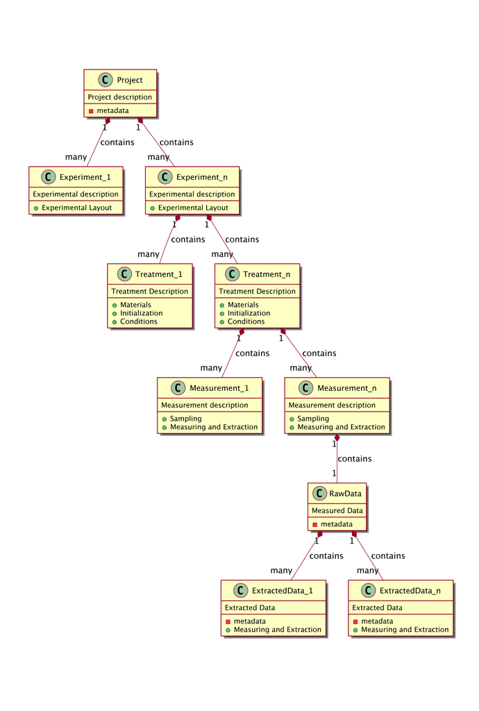

# References

Altermatt, Florian, Emanuel Fronhofer, Aurélie Garnier, Andrea Giometto, Frederik Hammes, Jan Klecka, Delphine Legrand, et al. 2015. “Big Answers from Small Worlds: A User’s Guide for Protist Microcosms as a Model System in Ecology and Evolution.” *Methods in Ecology and Evolution* 6 (2): 218–31. https://doi.org/10.1111/2041-210X.12312.

Carrara, Francesco, Andrea Giometto, Mathew Seymour, Andrea Rinaldo, and Florian Altermatt. 2015. “Experimental Evidence for Strong Stabilizing Forces at High Functional Diversity of Microbial Communities.” *Ecology* in press. https://doi.org/10.1890/14-1324.1.

DeLong, John P. 2012. “Experimental Demonstration of a ‘Rate–Size’ Trade-Off Governing Body Size Optimization.” *Evolutionary Ecology Research* 14 (3): 343–52. http://www.evolutionary-ecology.com/abstracts/v14/2742.html.

Fox, Jeremy W. 2002. “Testing a Simple Rule for Dominance in Resource Competition.” *The American Naturalist* 159 (3): 305–19. https://doi.org/10.1086/338543.

Griffiths, Jason I., Owen L. Petchey, Frank Pennekamp, and Dylan Z. Childs. 2018. “Linking Intraspecific Trait Variation to Community Abundance Dynamics Improves Ecological Predictability by Revealing a Growth–Defence Trade-Off.” *Functional Ecology* 32 (2): 496–508. https://doi.org/10.1111/1365-2435.12997.

Jiang, Lin, and Shivani N. Patel. 2008. “Community Assembly in the Presence of Disturbance: A Microcosm Experiment.” *Ecology* 89 (7): 1931–40. https://doi.org/10.1890/07-1263.1.

Leary, Daniel J., Jason M. K. Rip, and Owen L. Petchey. 2012. “The Impact of Environmental Variability and Species Composition on the Stability of Experimental Microbial Populations and Communities.” *Oikos* 121 (3): 327–36. https://doi.org/10.1111/j.1600-0706.2011.19523.x.

McGrady-Steed, J, and PM Harris. 1997. “Biodiversity Regulates Ecosystem Predictability.” *Nature* 390: 162–65. http://www.nature.com/nature/journal/v390/n6656/abs/390162a0.html.

Pennekamp, Frank, Mikael Pontarp, Andrea Tabi, Florian Altermatt, Roman Alther, Yves Choffat, Emanuel A. Fronhofer, et al. 2018. “Biodiversity Increases and Decreases Ecosystem Stability.” *Nature*, October. https://doi.org/10.1038/s41586-018-0627-8.

Petchey, Owen L. 2000. “Prey Diversity, Prey Composition, and Predator Population Dynamics in Experimental Microcosms.” *Journal of Animal Ecology* 69 (5): 874–82. https://doi.org/10.1046/j.1365-2656.2000.00446.x.

Vasseur, David A., and Jeremy W. Fox. 2009. “Phase-Locking and Environmental Fluctuations Generate Synchrony in a Predator–Prey Community.” *Nature* 460 (7258): 1007–10. https://doi.org/10.1038/nature08208.